# Comparing ΔT methods for the sensible heat flux

The sensible heat flux in `run_ice_model()` is

*Q<sub>h</sub> = ρ<sub>air</sub> · C<sub>a</sub> · C<sub>h</sub> · U · ΔT*

where ΔT is the difference between the air and ice-surface temperatures. The model does not track a separate surface temperature (its top node is held at the air temperature), so ΔT has to be estimated. This report runs every lake once per method, **changing nothing but ΔT**, and compares the results.

| delta_T_method | Label | Surface temperature (ΔT = T_air − T_s) |
| --- | --- | --- |
| `lag` | Lag (original) | T_s = previous hour’s T_air, so ΔT = T_air(t) − T_air(t−1) |
| `ashton` | Ashton | T_s where conduction through the ice balances air–surface exchange |
| `lwr_out` | LWR_out | T_s = (LWR_out / εσ)^¼, capped at 0 °C |
| `energy_balance` | Energy balance | T_s solved from the full surface energy balance, capped at 0 °C |

Only Q<sub>h</sub> changes directly. The heat-conduction boundary (top node = T<sub>air</sub>), the conductive flux Q<sub>c</sub> and the outgoing longwave are the same for every method, and the open-water phase at the Rockies lakes is unchanged (ΔT = T<sub>air</sub> − T<sub>water</sub>). Every other difference below is a knock-on effect of Q<sub>h</sub> through melt and ice thickness.

## Model runs

| Lake | Method | Status | Run time (min) |
| --- | --- | --- | --- |
| West Lake Bonney | Lag (original) | OK | 0.1 |
| West Lake Bonney | Ashton | OK | 0.1 |
| West Lake Bonney | LWR_out | OK | 0.1 |
| West Lake Bonney | Energy balance | OK | 0.2 |
| East Lake Bonney | Lag (original) | OK | 0.1 |
| East Lake Bonney | Ashton | OK | 0.1 |
| East Lake Bonney | LWR_out | OK | 0.1 |
| East Lake Bonney | Energy balance | OK | 0.2 |
| Lake Hoare | Lag (original) | OK | 0.1 |
| Lake Hoare | Ashton | OK | 0.1 |
| Lake Hoare | LWR_out | OK | 0.1 |
| Lake Hoare | Energy balance | OK | 0.1 |
| Lake Fryxell | Lag (original) | OK | 0.1 |
| Lake Fryxell | Ashton | OK | 0.1 |
| Lake Fryxell | LWR_out | OK | 0.1 |
| Lake Fryxell | Energy balance | OK | 0.1 |
| Green Lake 4 | Lag (original) | OK | 0.1 |
| Green Lake 4 | Ashton | OK | 0.1 |
| Green Lake 4 | LWR_out | OK | 0.1 |
| Green Lake 4 | Energy balance | OK | 0.2 |
| The Loch | Lag (original) | OK | 0.1 |
| The Loch | Ashton | OK | 0.1 |
| The Loch | LWR_out | OK | 0.1 |
| The Loch | Energy balance | OK | 0.1 |

## Ice thickness

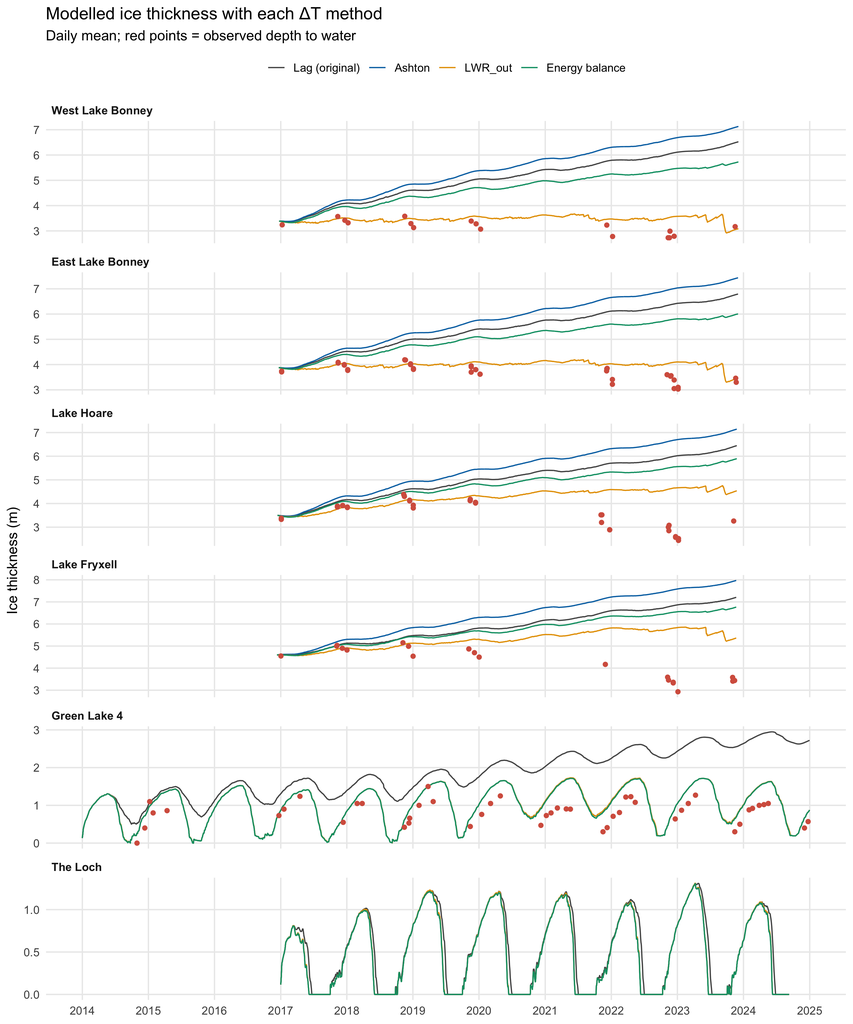

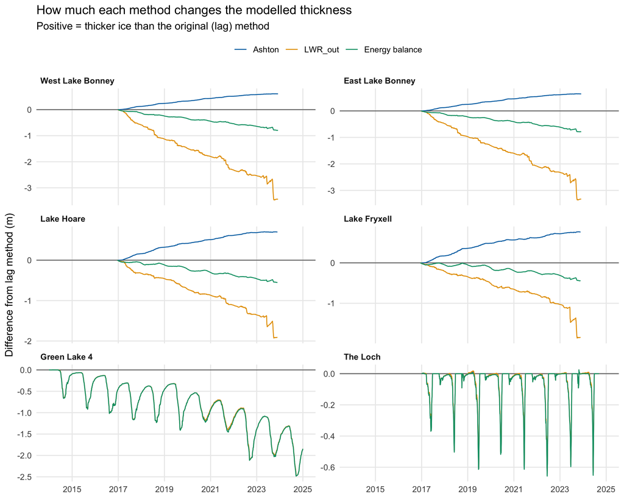

### Fit to observations

Model − observed depth to water: bias / RMSE (m). Bold = lowest RMSE for that lake and period.

| Lake | Method | Before Jul 2021 | Jul 2021 onward | All |
| --- | --- | --- | --- | --- |
| West Lake Bonney | Lag (original) | +1.12 / 1.26 | +3.12 / 3.13 | +1.94 / 2.23 |
| West Lake Bonney | Ashton | +1.33 / 1.49 | +3.68 / 3.69 | +2.30 / 2.63 |
| West Lake Bonney | LWR_out | **+0.17 / 0.24** | **+0.53 / 0.62** | **+0.32 / 0.44** |
| West Lake Bonney | Energy balance | +0.91 / 1.03 | +2.50 / 2.51 | +1.56 / 1.79 |
| East Lake Bonney | Lag (original) | +0.98 / 1.10 | +2.91 / 2.94 | +1.73 / 2.02 |
| East Lake Bonney | Ashton | +1.20 / 1.35 | +3.50 / 3.52 | +2.09 / 2.44 |
| East Lake Bonney | LWR_out | **+0.14 / 0.23** | **+0.53 / 0.64** | **+0.29 / 0.44** |
| East Lake Bonney | Energy balance | +0.78 / 0.89 | +2.31 / 2.34 | +1.38 / 1.62 |
| Lake Hoare | Lag (original) | +0.47 / 0.56 | +2.94 / 2.98 | +1.44 / 1.92 |
| Lake Hoare | Ashton | +0.73 / 0.84 | +3.60 / 3.63 | +1.86 / 2.37 |
| Lake Hoare | LWR_out | **+0.05 / 0.18** | **+1.65 / 1.69** | **+0.68 / 1.07** |
| Lake Hoare | Energy balance | +0.37 / 0.45 | +2.52 / 2.56 | +1.22 / 1.64 |
| Lake Fryxell | Lag (original) | +0.53 / 0.69 | +3.43 / 3.46 | +1.77 / 2.32 |
| Lake Fryxell | Ashton | +0.84 / 1.02 | +4.15 / 4.18 | +2.26 / 2.84 |
| Lake Fryxell | LWR_out | **+0.22 / 0.39** | **+2.16 / 2.20** | **+1.05 / 1.47** |
| Lake Fryxell | Energy balance | +0.48 / 0.63 | +3.09 / 3.12 | +1.60 / 2.09 |
| Green Lake 4 | Lag (original) | +0.82 / 0.92 | +1.77 / 1.79 | +1.23 / 1.36 |
| Green Lake 4 | Ashton | +0.32 / 0.39 | +0.44 / 0.45 | +0.37 / 0.42 |
| Green Lake 4 | LWR_out | +0.32 / 0.39 | +0.44 / 0.45 | +0.37 / 0.42 |
| Green Lake 4 | Energy balance | **+0.32 / 0.38** | **+0.43 / 0.44** | **+0.36 / 0.41** |

## ΔT and surface temperature

Monthly means over ice-covered hours. The original (lag) ΔT averages to almost zero, because it is just the hour-to-hour change in air temperature. The other methods give a real air-minus-surface difference: negative when the surface is warmer than the air (heat flows from the ice to the air), positive when the air is warmer.

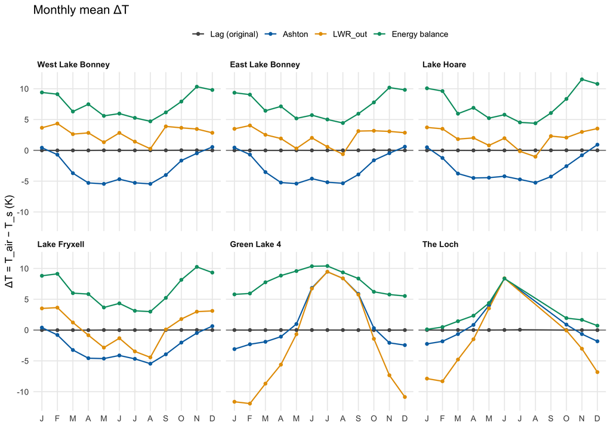

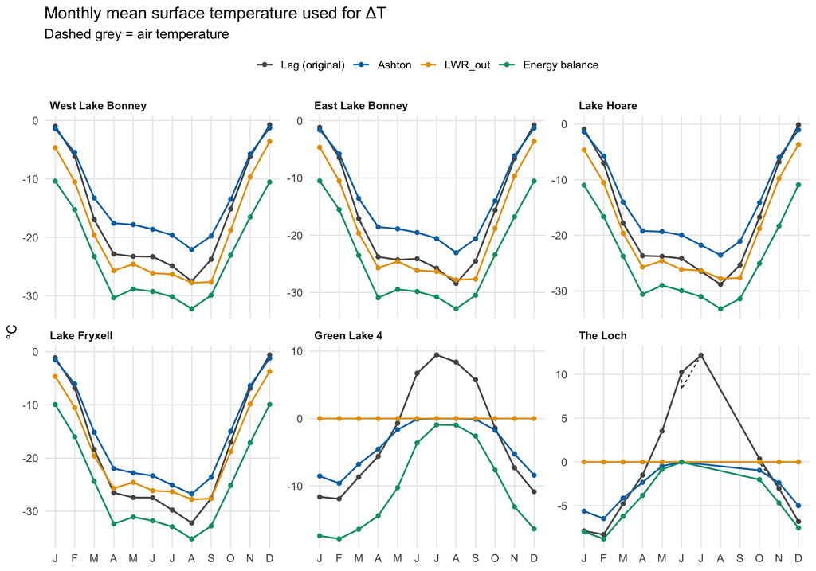

### Check against measured outgoing longwave (Dry Valley lakes)

At the Dry Valley lakes the outgoing longwave comes from the COHM station, so it gives an independent surface-temperature estimate, T<sub>s</sub> = (LWR<sub>out</sub> / εσ)^¼. COHM is on Commonwealth Glacier, not on the lakes, so this is a check on the seasonal pattern and size of T<sub>s</sub>, not an exact target. (The `lwr_out` method uses this estimate directly, so it matches by construction. At the Rockies lakes LWR<sub>out</sub> is a constant, so this check is skipped there.)

Modelled surface temperature vs the LWR_out estimate (hourly, ice-covered)

| Lake | Method | Bias (K) | RMSE (K) | r (hourly) |
| --- | --- | --- | --- | --- |
| West Lake Bonney | Lag (original) | 2.74 | 6.83 | 0.86 |
| West Lake Bonney | Ashton | 5.76 | 8.78 | 0.78 |
| West Lake Bonney | LWR_out | 0.00 | 0.00 | 1.00 |
| West Lake Bonney | Energy balance | -4.56 | 7.42 | 0.85 |
| East Lake Bonney | Lag (original) | 2.19 | 6.69 | 0.86 |
| East Lake Bonney | Ashton | 5.13 | 8.38 | 0.79 |
| East Lake Bonney | LWR_out | 0.00 | 0.00 | 1.00 |
| East Lake Bonney | Energy balance | -4.95 | 7.68 | 0.85 |
| Lake Hoare | Lag (original) | 1.94 | 6.46 | 0.87 |
| Lake Hoare | Ashton | 4.83 | 8.01 | 0.81 |
| Lake Hoare | LWR_out | 0.00 | 0.00 | 1.00 |
| Lake Hoare | Energy balance | -5.45 | 7.79 | 0.86 |
| Lake Fryxell | Lag (original) | 0.24 | 7.11 | 0.86 |
| Lake Fryxell | Ashton | 3.01 | 7.40 | 0.81 |
| Lake Fryxell | LWR_out | 0.00 | 0.00 | 1.00 |
| Lake Fryxell | Energy balance | -6.11 | 8.31 | 0.88 |

## Sensible heat flux

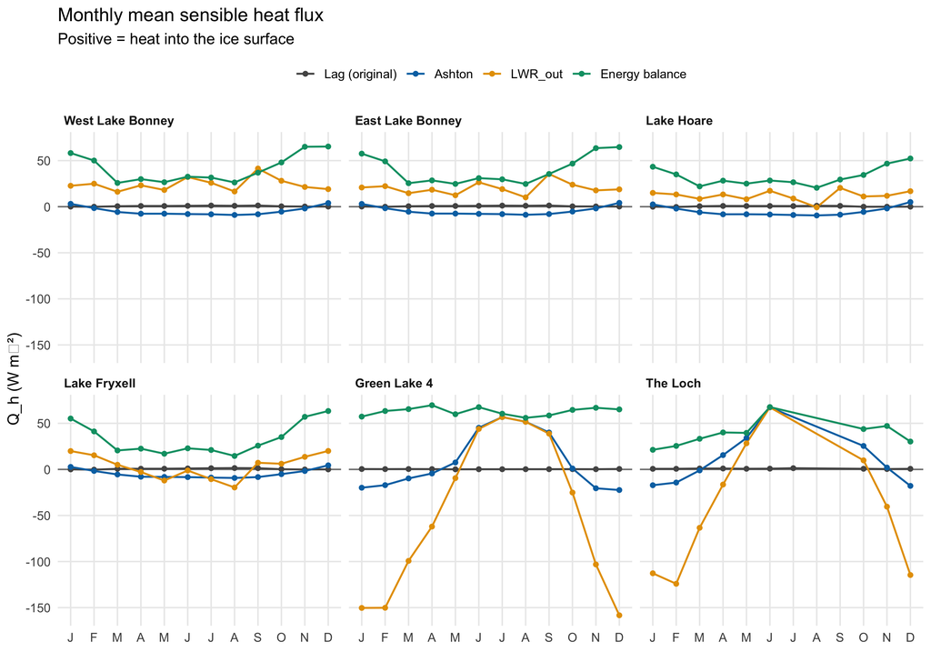

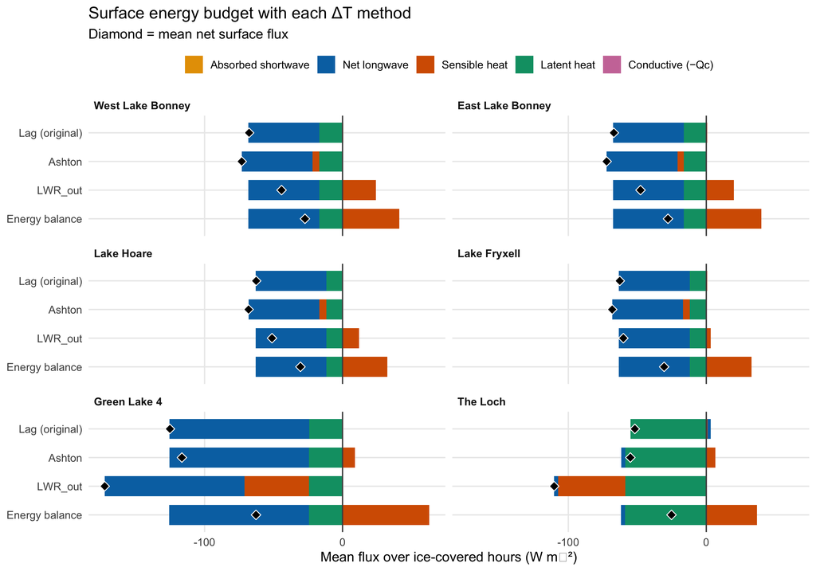

Sensible heat flux over ice-covered hours (W m⁻²)

| Lake | Method | Mean ΔT (K) | Mean Qh | Mean \|Qh\| | Qh 5th pct | Qh 95th pct |
| --- | --- | --- | --- | --- | --- | --- |
| West Lake Bonney | Lag (original) | 0.0 | 0.6 | 4.9 | -10.3 | 12.6 |
| West Lake Bonney | Ashton | -3.0 | -4.8 | 6.3 | -13.1 | 3.7 |
| West Lake Bonney | LWR_out | 2.7 | 24.1 | 37.9 | -36.6 | 137.1 |
| West Lake Bonney | Energy balance | 7.3 | 41.1 | 42.2 | -2.7 | 114.6 |
| East Lake Bonney | Lag (original) | 0.0 | 0.6 | 5.0 | -10.1 | 13.2 |
| East Lake Bonney | Ashton | -2.9 | -4.6 | 6.2 | -12.6 | 3.5 |
| East Lake Bonney | LWR_out | 2.2 | 20.0 | 36.8 | -44.6 | 127.7 |
| East Lake Bonney | Energy balance | 7.1 | 39.9 | 41.1 | -3.3 | 112.3 |
| Lake Hoare | Lag (original) | 0.0 | 0.4 | 5.5 | -12.6 | 13.7 |
| Lake Hoare | Ashton | -2.9 | -5.1 | 6.7 | -13.6 | 4.1 |
| Lake Hoare | LWR_out | 1.9 | 11.9 | 29.4 | -43.6 | 102.8 |
| Lake Hoare | Energy balance | 7.4 | 32.5 | 33.9 | -4.6 | 102.5 |
| Lake Fryxell | Lag (original) | 0.0 | 0.6 | 5.6 | -11.9 | 13.8 |
| Lake Fryxell | Ashton | -2.8 | -4.9 | 6.4 | -12.9 | 3.4 |
| Lake Fryxell | LWR_out | 0.2 | 3.2 | 34.6 | -69.8 | 84.0 |
| Lake Fryxell | Energy balance | 6.4 | 32.8 | 35.2 | -9.1 | 103.4 |
| Green Lake 4 | Lag (original) | 0.0 | 0.3 | 4.8 | -10.3 | 12.4 |
| Green Lake 4 | Ashton | 1.6 | 9.1 | 27.9 | -35.1 | 84.3 |
| Green Lake 4 | LWR_out | -2.3 | -46.9 | 83.9 | -280.8 | 84.3 |
| Green Lake 4 | Energy balance | 7.8 | 62.8 | 63.0 | 1.6 | 146.2 |
| The Loch | Lag (original) | 0.0 | 0.7 | 6.6 | -12.9 | 18.5 |
| The Loch | Ashton | 0.3 | 6.6 | 29.0 | -39.6 | 103.9 |
| The Loch | LWR_out | -3.0 | -48.7 | 84.3 | -270.1 | 104.0 |
| The Loch | Energy balance | 2.0 | 36.6 | 45.0 | -22.5 | 154.3 |

## Surface melt and bottom growth

Totals per ice year (July–June, labelled by the year it ends in).

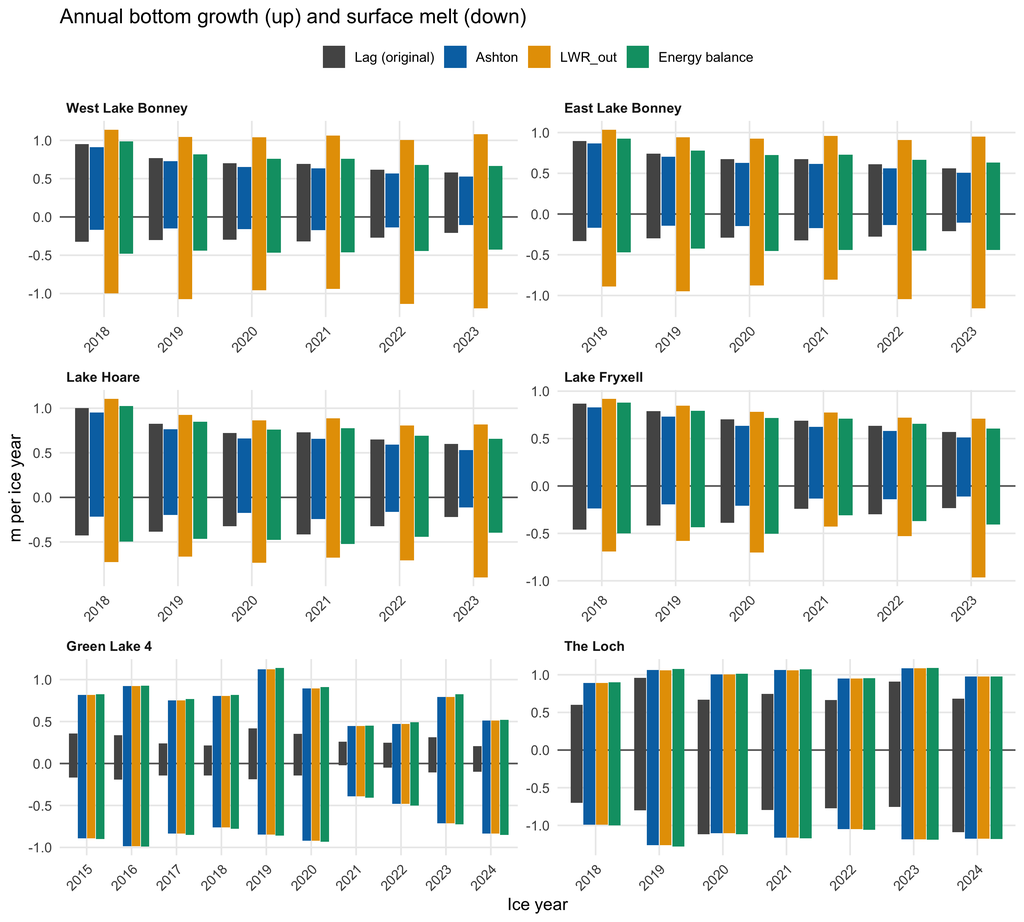

Mean per complete ice year

| Lake | Method | Bottom growth (m/yr) | Surface melt (m/yr) | Net (m/yr) |
| --- | --- | --- | --- | --- |
| West Lake Bonney | Lag (original) | 0.72 | -0.29 | 0.43 |
| West Lake Bonney | Ashton | 0.67 | -0.15 | 0.52 |
| West Lake Bonney | LWR_out | 1.06 | -1.05 | 0.01 |
| West Lake Bonney | Energy balance | 0.78 | -0.45 | 0.32 |
| East Lake Bonney | Lag (original) | 0.69 | -0.29 | 0.41 |
| East Lake Bonney | Ashton | 0.65 | -0.14 | 0.50 |
| East Lake Bonney | LWR_out | 0.95 | -0.95 | 0.00 |
| East Lake Bonney | Energy balance | 0.74 | -0.45 | 0.30 |
| Lake Hoare | Lag (original) | 0.75 | -0.35 | 0.41 |
| Lake Hoare | Ashton | 0.69 | -0.18 | 0.51 |
| Lake Hoare | LWR_out | 0.90 | -0.73 | 0.17 |
| Lake Hoare | Energy balance | 0.79 | -0.47 | 0.33 |
| Lake Fryxell | Lag (original) | 0.71 | -0.34 | 0.37 |
| Lake Fryxell | Ashton | 0.65 | -0.17 | 0.48 |
| Lake Fryxell | LWR_out | 0.79 | -0.65 | 0.14 |
| Lake Fryxell | Energy balance | 0.73 | -0.42 | 0.31 |
| Green Lake 4 | Lag (original) | 0.30 | -0.13 | 0.17 |
| Green Lake 4 | Ashton | 0.75 | -0.77 | -0.01 |
| Green Lake 4 | LWR_out | 0.75 | -0.77 | -0.01 |
| Green Lake 4 | Energy balance | 0.77 | -0.78 | -0.01 |
| The Loch | Lag (original) | 0.75 | -0.86 | -0.11 |
| The Loch | Ashton | 1.00 | -1.13 | -0.13 |
| The Loch | LWR_out | 1.00 | -1.13 | -0.13 |
| The Loch | Energy balance | 1.01 | -1.14 | -0.13 |

## Notes

- **Why the Ashton, LWR_out and energy-balance runs can give almost the same thickness.** The model only acts on the net surface flux when it is positive (surface melt); a negative net flux is discarded, and bottom growth depends on the air-temperature-pinned profile, not on Q<sub>h</sub>. So winter differences in Q<sub>h</sub> never reach the ice thickness. During melt, all three methods cap T<sub>s</sub> at 0 °C, so they share the same ΔT = T<sub>air</sub> − 0 °C and the same melt. The lag method is the odd one out because its ΔT is near zero during melt too.
- **What differs between methods.** Only ΔT, and so Q<sub>h</sub>, in the ice phase. The ice’s top node is still set to the air temperature in every run, so the conductive flux Q<sub>c</sub> and the temperature profile respond to T<sub>air</sub>, not to the T<sub>s</sub> each method estimates.
- **Ashton.** T<sub>s</sub> comes from balancing conduction through the whole ice thickness against air–surface exchange (H = ρ<sub>air</sub> C<sub>a</sub> C<sub>h</sub> U), with no radiation. Thick ice conducts little, so T<sub>s</sub> sits close to T<sub>air</sub> and ΔT stays small.
- **LWR_out.** Uses the measured COHM outgoing longwave at the Dry Valley lakes. At the Rockies lakes LWR<sub>out</sub> is a constant (εσT<sub>f</sub>⁴), so T<sub>s</sub> = 0 °C and ΔT = T<sub>air</sub> − 0 °C, which overstates winter heat loss.
- **Energy balance.** Solves for T<sub>s</sub> each hour from shortwave, longwave, sensible, latent and conduction (linear profile to 0 °C at the ice base), with T<sub>s</sub> capped at 0 °C.
- Raw outputs are in `Data/model_outputs/deltaT_comparison/`.

Settings used by every run in this report

| Lake | Chi (fraction of SW not absorbed at the surface) | Ch (sensible transfer coeff.) |
| --- | --- | --- |
| West Lake Bonney | 1 | 0.0013 |
| East Lake Bonney | 1 | 0.0013 |
| Lake Hoare | 1 | 0.0013 |
| Lake Fryxell | 1 | 0.0013 |
| Green Lake 4 | 1 | 0.0013 |
| The Loch | 1 | 0.0013 |